# Calculate Medians for Dashboard - Longitudinal

Author

Judah Axelrod and Aaron R. Williams, Updated by Kassandra Martinchek

Published

May 18, 2026

# Mobility metrics median calculations

This code calculates weighted medians of the mobility metrics at the county level.

We exclude missing values and calculate the proportion of counties and proportion of population missing for each metric. The function below is used to calculate the proportion of population missing for each metric.

```r
missing_share <- function(x, weight) {

  sum(as.numeric(is.na(x)) * weight) / sum(weight)

}
```

The steps taken for calculating the median estimates are as follow:

- Calculate the population-weighted median.
- For each median, calculate the proportion of counties that are missing.
- For each median, calculate the proportion of people that are missing

## Load Packages

```r
options(scipen = 999)

library(tidyverse)
library(here)
library(tidycensus)
library(kableExtra)
```

## Load Data

```r
metrics <- read_csv(here("data", "11_mobility-metrics_county_longitudinal.csv")) |>
  select(-ends_with("_lb"), -ends_with("_ub"))
```

## Calculate Medians

We calculate the median for each variable weighted by the county-level population. This means our estimates represent the county mobility metric for the average American.

`Hmisc::wtd.quantile()` fails when there are zero non-`NA` points. We create `safe_wtd_quantile()` to simplify our calculations when there are missing variable-year combinations.

```r
safe_wtd_quantile <- possibly(Hmisc::wtd.quantile, otherwise = NA)
```

Compute population-weighted median for each metric by year.

```r
weighted_median <- metrics |>
  select(where(is.numeric) & (!ends_with("quality"))) |>
  group_by(year) |>
  summarize(
    across(
      .cols = -population,
      .fns = ~ safe_wtd_quantile(., weights = population, probs = 0.5, na.rm = TRUE)
    )
  ) |>
  pivot_longer(cols = -year, values_to = "weighted_median")
```

## Quality Evaluation

Compute the number of states with marginal or better data quality for each metric for each year.

```r
state_count <- metrics |>
  mutate(
    across(
      .cols = ends_with("quality"),
      .fns = ~ case_when(
        . == "Strong" ~ 1,
        . == "Marginal" ~ 2,
        . == "Weak" ~ 3)
    )
  ) |>
  pivot_longer(
    cols = ends_with("_quality"),
    names_to = "qual_varname",
    values_to = "quality"
  ) |>
  filter(quality %in% 1:2) |>
  count(state_name, year, qual_varname) |>
  count(qual_varname, year, name = "n_states")
```

Compute the proportion of the population with marginal quality or weak quality for each variable for each year.

```r
proportion_by_qual <- metrics |>
  mutate(
    across(
      .cols = ends_with("quality"),
      .fns = ~ case_when(
        . == "Strong" ~ 1,
        . == "Marginal" ~ 2,
        . == "Weak" ~ 3
      )
    )
  ) |>
  select(where(is.numeric)) |>
  pivot_longer(
    cols = ends_with("_quality"),
    names_to = "qual_varname",
    values_to = "quality"
  ) |>
  group_by(year, qual_varname, quality) |>
  summarize(population = sum(population)) |>
  group_by(year, qual_varname) |>
  mutate(pop_share = population / sum(population)) |>
  filter(quality %in% 2:3) |>
  select(-population) |>
  arrange(qual_varname, quality) |>
  ungroup()
```

Compute proportion of population missing for each metric.

```r
missing_population <- metrics |>
  select(where(is.numeric) & (!ends_with("quality"))) |>
  group_by(year) |>
  summarize(
    across(
      .cols = -population,
      .fns = ~ missing_share(.x, weight = population)
    )
  ) |>
  pivot_longer(cols = -year, values_to = "missing_population")
```

Compute share of counties missing for each metric.

```r
missing_county <- metrics |>
  select(where(is.numeric) & (!ends_with("quality"))) |>
  group_by(year) |>
  summarize(
    across(
      .cols = -population,
      .fns = ~ sum(is.na(.x)) / n()
    )
  ) |>
  pivot_longer(cols = -year, values_to = "missing_county")
```

Compute population-weighted 5th and 95th percentiles.

```r
low_pctle <- metrics |>
  select(where(is.numeric) & (!ends_with("quality"))) |>
  group_by(year) |>
  summarize(
    across(
      .cols = -population,
      .fns = ~ safe_wtd_quantile(., weights = population, probs = 0.05, na.rm = TRUE)
    )
  ) |>
  pivot_longer(cols = -year, values_to = "low_pctle")

high_pctle <- metrics |>
  select(where(is.numeric) & (!ends_with("quality"))) |>
  group_by(year) |>
  summarize(
    across(
      .cols = -population,
      .fns = ~safe_wtd_quantile(., weights = population, probs = 0.95, na.rm = TRUE)
    )
  ) |>
  pivot_longer(cols = -year, values_to = "high_pctle")
```

## Final Data

Combine all of the metrics calculated above.

```r
weighted_med_table <- weighted_median |>
  full_join(low_pctle, by = c("year", "name")) |>
  full_join(high_pctle, by = c("year", "name")) |>
  full_join(missing_population, by = c("year", "name")) |>
  full_join(missing_county, by = c("year", "name")) |>
  mutate(qual_varname = paste0(name, "_quality")) |>
  left_join(proportion_by_qual, by = c("year", "qual_varname")) |>  #M:M Merge is expected behavior here
  left_join(state_count, by = c("year", "qual_varname"))
```

`proportion_by_qual` double the number of rows. Pivot the data wider so there is one row per metric per year.

```r
weighted_med_table <- weighted_med_table |>
  pivot_wider(names_from = quality, names_glue = "quality{quality}_popshare", values_from = pop_share)
```

Round values and calculate the proportion of the population for each metric that is either missing or has data quality equal to three.

```r
weighted_med_table <- weighted_med_table |>
  select(-qual_varname, -qualityNA_popshare) |>
  mutate(across(.cols = where(is.numeric), .fns = ~ round(., digits = 4))) |>
  rowwise() |>
  # Share of pop that is either missing or quality = 3 for that metric
  mutate(share_lq3 = sum(missing_population, quality3_popshare, na.rm = TRUE)) |>
  # Remove all-missing metric-years
  filter(missing_county < 1 & name != "population") |>
  ungroup()
```

Print the table.

```r
weighted_med_table |>
  arrange(name) |>
  kbl() |>
  kable_styling(font_size = 10, fixed_thead = TRUE)
```

| year | name | weighted_median | low_pctle | high_pctle | missing_population | missing_county | n_states | quality2_popshare | quality3_popshare | share_lq3 |
| --- | --- | --- | --- | --- | --- | --- | --- | --- | --- | --- |
| 2014 | count_homeless | 1478.0000 | 51.0000 | 30120.0000 | 0.0308 | 0.2508 | 52 | 0.0153 | 0.0315 | 0.0623 |
| 2015 | count_homeless | 1517.0000 | 53.0000 | 34695.0000 | 0.0284 | 0.2406 | 51 | 0.0092 | 0.0323 | 0.0607 |
| 2016 | count_homeless | 1584.0000 | 56.0000 | 33871.0000 | 0.0244 | 0.2237 | 51 | 0.0136 | 0.0283 | 0.0527 |
| 2017 | count_homeless | 1688.0000 | 59.0000 | 48036.0000 | 0.0228 | 0.2116 | 50 | 0.0085 | 0.0255 | 0.0483 |
| 2018 | count_homeless | 1606.0000 | 56.0000 | 31807.0000 | 0.0194 | 0.1970 | 51 | 0.0077 | 0.0249 | 0.0443 |
| 2019 | count_homeless | 1439.0000 | 52.0000 | 32521.0000 | 0.0214 | 0.2116 | 51 | 0.0121 | 0.0269 | 0.0483 |
| 2020 | count_homeless | 1157.0000 | 48.0000 | 25692.0000 | 0.0225 | 0.2211 | 51 | 0.0130 | 0.0310 | 0.0535 |
| 2021 | count_homeless | 1385.0000 | 53.0000 | 26139.0000 | 0.0202 | 0.2043 | 51 | 0.0099 | 0.0271 | 0.0473 |
| 2022 | count_homeless | 1631.0000 | 63.0000 | 27249.0000 | 0.0174 | 0.1902 | 51 | 0.0100 | 0.0259 | 0.0433 |
| 2014 | count_membership_associations_per_10k | 8.9000 | 4.5000 | 16.2000 | 0.0001 | 0.0073 | 52 | NA | NA | 0.0001 |
| 2015 | count_membership_associations_per_10k | 8.8000 | 4.6000 | 16.1000 | 0.0001 | 0.0076 | 51 | NA | NA | 0.0001 |
| 2016 | count_membership_associations_per_10k | 8.8000 | 4.6000 | 16.1000 | 0.0001 | 0.0080 | 51 | NA | NA | 0.0001 |
| 2017 | count_membership_associations_per_10k | 8.6000 | 4.5000 | 15.1000 | 0.0017 | 0.0449 | 51 | NA | NA | 0.0017 |
| 2018 | count_membership_associations_per_10k | 8.6000 | 4.5000 | 15.0000 | 0.0016 | 0.0439 | 51 | NA | NA | 0.0016 |
| 2019 | count_membership_associations_per_10k | 8.5000 | 4.5000 | 15.0000 | 0.0016 | 0.0449 | 51 | NA | NA | 0.0016 |
| 2020 | count_membership_associations_per_10k | 8.2000 | 4.4000 | 14.6000 | 0.0019 | 0.0484 | 51 | NA | NA | 0.0019 |
| 2021 | count_membership_associations_per_10k | 8.2000 | 4.4000 | 14.7000 | 0.0018 | 0.0490 | 51 | NA | NA | 0.0018 |
| 2022 | count_membership_associations_per_10k | 8.3000 | 4.5000 | 14.6000 | 0.0019 | 0.0477 | 51 | NA | NA | 0.0019 |
| 2023 | count_membership_associations_per_10k | 8.3000 | 4.5000 | 14.6000 | 0.0019 | 0.0496 | 51 | NA | NA | 0.0019 |
| 2014 | index_air_hazard | 46.0000 | 10.0000 | 93.0000 | 0.0001 | 0.0010 | 52 | NA | NA | 0.0001 |
| 2018 | index_air_hazard | 44.0000 | 11.0000 | 83.0000 | 0.0000 | 0.0003 | 51 | NA | NA | 0.0000 |
| 2019 | index_air_hazard | 44.0000 | 11.0000 | 84.0000 | 0.0000 | 0.0003 | 51 | NA | NA | 0.0000 |
| 2014 | pctl_income_20 | 28741.0000 | 19250.0000 | 49194.0000 | 0.0037 | 0.1127 | 52 | 0.1052 | 0.1201 | 0.1238 |
| 2015 | pctl_income_20 | 30617.0000 | 19881.0000 | 51161.0000 | 0.0035 | 0.1111 | 51 | 0.1048 | 0.1192 | 0.1227 |
| 2016 | pctl_income_20 | 31233.0000 | 19751.0000 | 52274.0000 | 0.0037 | 0.1149 | 51 | 0.1047 | 0.1184 | 0.1221 |
| 2017 | pctl_income_20 | 32322.0000 | 20169.0000 | 51715.0000 | 0.0037 | 0.1149 | 51 | 0.1042 | 0.1175 | 0.1212 |
| 2018 | pctl_income_20 | 32758.0000 | 20363.0000 | 53500.0000 | 0.0036 | 0.1127 | 51 | 0.1043 | 0.1172 | 0.1208 |
| 2019 | pctl_income_20 | 34477.0000 | 21703.0000 | 55808.0000 | 0.0034 | 0.1111 | 51 | 0.1043 | 0.1170 | 0.1204 |
| 2021 | pctl_income_20 | 32442.0000 | 20634.0000 | 53672.0000 | 0.0035 | 0.1149 | 51 | 0.1044 | 0.1157 | 0.1192 |
| 2022 | pctl_income_20 | 33503.0000 | 21107.0000 | 54721.0000 | 0.0032 | 0.1110 | 51 | 0.0984 | 0.1112 | 0.1144 |

[output cut: 254 more lines]

Visualize the proportion of the population behind each metric with missing values or data quality equal to three.

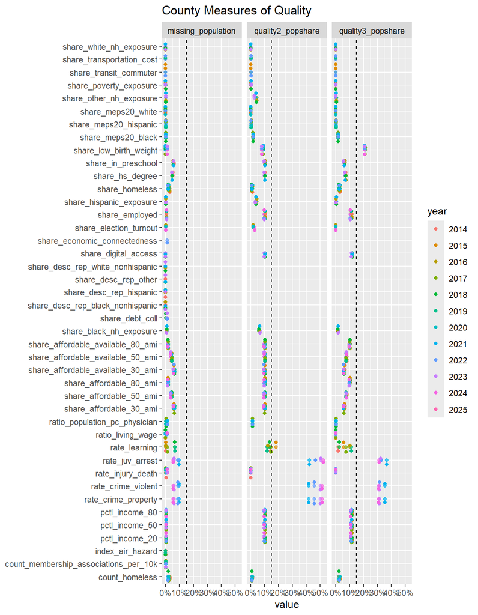

```r
weighted_med_table |>
  select(year,name, missing_population, quality2_popshare, quality3_popshare) |>
  pivot_longer(
    cols = -c(year, name),
    names_to = "measure",
    values_to = "value"
  ) |>
  mutate(year = as.factor(year)) |>
  ggplot(aes(x = value, y = name, color = year)) +
  geom_point(alpha = 0.7) +
  geom_jitter() +
  geom_vline(xintercept = 0.15, linetype="dashed") +
  scale_x_continuous(labels = scales::percent) +
  facet_wrap(~ measure) +
  labs(
    title = "County Measures of Quality",
    y = NULL
  )
```

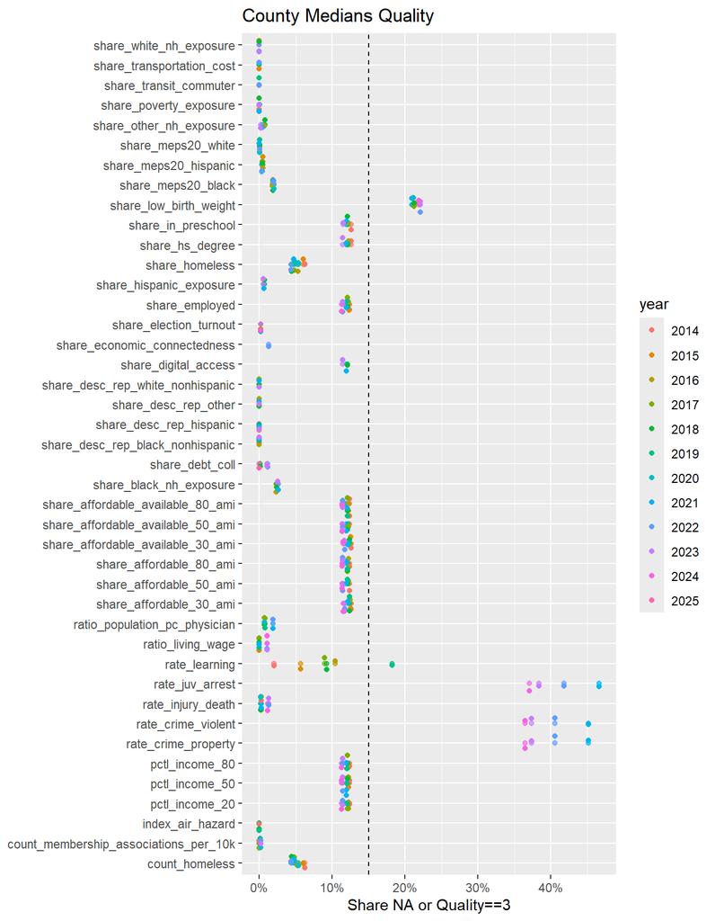

```r
weighted_med_table |>
  mutate(year = as.factor(year)) |>
  ggplot(aes(x = share_lq3, y = name, color = year)) +
  geom_point(alpha = 0.7) +
  geom_jitter() +
  geom_vline(xintercept = 0.15, linetype="dashed") +
  scale_x_continuous(labels = scales::percent) +
  labs(
    title = "County Medians Quality",
    x = "Share NA or Quality==3",
    y = NULL
  )
```

## Save the Data

Suppress medians if the more than 15% of the population is missing represented by data quality equal to 3. Select final variables and write to .csv.

```r
final_table <- weighted_med_table |>
  mutate(group = "wtd_med", weighted_median = ifelse(share_lq3 > 0.15, NA, weighted_median)) |>
  select(year, group, name, weighted_median) |>
  pivot_wider(names_from = name, values_from = weighted_median)

final_table |>
  write_csv(here("99_construct-database", "county_medians_year_suppressed.csv"))
```